# Assignment 1; Distribution Testing and The Bootstrap

```python
# Normal Alternative: MAKE INTO A FUNCTION OF (alternative sampler, mu and sig) FOR PLOTTING
'''
Power of the KD and AD tests for the student's t null hypothesis, for significance levels alpha = 0.01, 0.05, and 0.1, with
sample sizes n = 30, 60, 100 and degrees of freedom df = 3, 6, 12, using the Gaussian and Laplacian alternatives.

Inputs:
    - alternative = alternative distribution sampler (from alt(mu, sig) where alt = normal or laplacian)
    - mu = location parameter of alternative distribution
    - sig = scale parameter of alternative distribution
    - it = number of simulations
Outputs:
    - A tuple of two dictionaries with keys '(df, n)' and values corresponding to an array of the recorded test powers at the
      three alpha levels (0.01, 0.05, 0.1) using the specified alternative distribution alt(mu, sig). Note: The first is for KD
      and second for AD.
'''
def KDAD_power_alt(alternative, mu, sig, it):
    KD_alt_power = {}
    AD_alt_power = {}

    for df in dfs:
        print(f'df={df} critvals')
        for n in ns:
            print(f'n={n}')
            # count rejections for rows representing critical values 0.01, 0.05, 0.1
            KDa_df_n_reject = np.zeros((3,it))
            ADa_df_n_reject = np.zeros((3,it))

            inds = np.arange(1,n+1)
            ecdf_y = (inds - 3/8) / (n + 1/4)


            for i in range(it):
                # generate and sort alternative data
                s = alternative(loc=mu, scale=sig, size = n)
                s = np.sort(s)

                # No closed formed expression for MLEs. Numerically optimize:
                bounds = [(-np.inf, np.inf), (1e-5, np.inf), (1e-5, 90)]
                params0 = [0, 1, df]
                res = optimize.minimize(lst_loglikelihood, params0, method='L-BFGS-B', args=s, bounds=bounds, tol=1e-6)

                # MLEs
                mu_mle, sig_mle, df_mle = res.x

                # Fitted student's t distribution
                cdf_y = stats.t.cdf(s, df = df_mle, loc = mu_mle, scale = sig_mle)


                # calculate KD
                KD_i = KD(ecdf_y, cdf_y)

                # calculate AD
                AD_i = AD(ecdf_y, cdf_y)

                # compare to critical values (for each alpha level) --> append 1 for correct rejection
                for a in range(3):
                    # KD
                    if KD_i >= KD_critvals[f'{df},{n}'][a]:
                        KDa_df_n_reject[a][i] = 1 # insert 1 for incorrect rejection
                    # AD
                    if AD_i >= AD_critvals[f'{df},{n}'][a]:
                        ADa_df_n_reject[a][i] = 1 # insert 1 for incorrect rejection


            # Calculate proportion of rejections (sum across rows and divide by length)
            KDa_df_n_power = np.array([])
            ADa_df_n_power = np.array([])

            # power of test for different alpha levels
            for a in range(3):
                KD_pow = np.sum(KDa_df_n_reject[a]) / it
                KDa_df_n_power = np.append(KDa_df_n_power, KD_pow)

                AD_pow = np.sum(ADa_df_n_reject[a]) / it
                ADa_df_n_power = np.append(ADa_df_n_power, AD_pow)

            KD_alt_power[f'{df},{n}'] = KDa_df_n_power
            AD_alt_power[f'{df},{n}'] = ADa_df_n_power

    return (KD_alt_power, AD_alt_power)
```

```python
'''
Expectations:
# General
 increasing alpha level -> decreases cutoff and makes it "easier" to not reject
 increasing sample size -> more accurate representation of simulated distribution -> greater power
# Normal
 increasing dfs --> t becomes closer to normal which should mean power decreases
 KD vs AD --> AD should have greater power due to greater tail sensitivity, as this is where normal and t vary the most
# Laplace
 increasing dfs --> less fat fails; excess kurtosis of LD is 3; infinite for t with 2 < df <= 4, else df > 4 it is < 6 / (df - 4)
                    df 3:  - t has significantly fatter tails (EK=inf) -> AD performs better
                           - t also narrower -> KD better at capturing this
                    df 6: t and l have same kurtosis -> expect KD better -> tail impact low
                    df 12: t has less kurtosis -> AD performs better


'''




np.random.seed(100)

mu = 0
sig = 1
it = 10000

norm_alt_powers = KDAD_power_alt(stats.norm.rvs, mu, sig, it)
```

```
df=3 critvals
n=30
n=60
n=100
df=6 critvals
n=30
n=60
n=100
df=12 critvals
n=30
n=60
n=100
```

```python
#KD
norm_alt_powers[0]
```

```
{'3,30': array([0.0236, 0.0934, 0.1742]),
 '3,60': array([0.0411, 0.1396, 0.2257]),
 '3,100': array([0.0533, 0.1605, 0.2436]),
 '6,30': array([0.015 , 0.0758, 0.1413]),
 '6,60': array([0.0193, 0.0923, 0.1747]),
 '6,100': array([0.0296, 0.1069, 0.1855]),
 '12,30': array([0.0139, 0.0675, 0.1249]),
 '12,60': array([0.0082, 0.0591, 0.1172]),
 '12,100': array([0.0158, 0.0716, 0.1304])}
```

```python
#AD
norm_alt_powers[1]
```

```
{'3,30': array([0.0024, 0.0187, 0.0372]),
 '3,60': array([0.0002, 0.0098, 0.0281]),
 '3,100': array([0.    , 0.0068, 0.0235]),
 '6,30': array([0.007 , 0.0326, 0.0698]),
 '6,60': array([0.002 , 0.0223, 0.0528]),
 '6,100': array([0.0006, 0.0128, 0.0352]),
 '12,30': array([0.0075, 0.0334, 0.0722]),
 '12,60': array([0.002 , 0.021 , 0.0493]),
 '12,100': array([0.0018, 0.0115, 0.0309])}
```

```python
mu = 0
sig = 1
it = 10000

lap_alt_powers = KDAD_power_alt(stats.laplace.rvs, mu, sig, it)
```

```
df=3 critvals
n=30
n=60
n=100
df=6 critvals
n=30
n=60
n=100
df=12 critvals
n=30
n=60
n=100
```

```python
lap_alt_powers[0]
```

```
{'3,30': array([0.0144, 0.0576, 0.112 ]),
 '3,60': array([0.0214, 0.0778, 0.1456]),
 '3,100': array([0.0249, 0.1015, 0.1767]),
 '6,30': array([0.0091, 0.0428, 0.0866]),
 '6,60': array([0.0112, 0.0491, 0.104 ]),
 '6,100': array([0.0136, 0.0696, 0.1337]),
 '12,30': array([0.0116, 0.0492, 0.0899]),
 '12,60': array([0.0119, 0.0562, 0.1069]),
 '12,100': array([0.0166, 0.0749, 0.1349])}
```

```python
lap_alt_powers[1]
```

```
{'3,30': array([0.006 , 0.0469, 0.0831]),
 '3,60': array([0.0009, 0.0257, 0.0671]),
 '3,100': array([0.    , 0.0119, 0.0466]),
 '6,30': array([0.0168, 0.0696, 0.1332]),
 '6,60': array([0.0089, 0.0484, 0.0998]),
 '6,100': array([0.0013, 0.0304, 0.0781]),
 '12,30': array([0.0145, 0.0736, 0.1443]),
 '12,60': array([0.0041, 0.053 , 0.1201]),
 '12,100': array([0.0029, 0.032 , 0.0897])}
```

```python
## DO FOR SEVERAL mus and sigs for normal and laplacian alternatives to show it does not change
mu = 0
sig = 1
it = 5000

mus = [-5, -2, 0, 2, 5]
sigs = [0.5, 1, 2, 3, 4]

# Normal alternative
for mu in mus:
    res = KDAD_power_alt(stats.norm.rvs, mu, sig, it)
    print(f'KD normal power with mu = {mu}, sig = {sig}:')
    print(res[0])
    print(f'AD normal power with mu = {mu}, sig = {sig}:')
    print(res[1])

for sig in sigs:
    res = KDAD_power_alt(stats.norm.rvs, mu, sig, it)
    print(f'KD normal power with sig = {sig}, mu = {mu}:')
    print(res[0])
    print(f'AD normal power with sig = {sig}, mu = {mu}:')
    print(res[1])


# Laplacian alternative
for mu in mus:
    res = KDAD_power_alt(stats.laplace.rvs, mu, sig, it)
    print(f'KD laplace power with mu = {mu}, sig = {sig}:')
    print(res[0])
    print(f'AD laplace power with mu = {mu}, sig = {sig}:')
    print(res[1])

for sig in sigs:
    res = KDAD_power_alt(stats.laplace.rvs, mu, sig, it)
    print(f'KD laplace power with sig = {sig}, mu = {mu}:')
    print(res[0])
    print(f'AD laplace power with sig = {sig}, mu = {mu}:')
    print(res[1])
```

```
df=3 critvals
n=30
n=60
n=100
df=6 critvals
n=30
n=60
n=100
df=12 critvals
n=30
n=60
n=100
KD normal power with mu = -5, sig = 1:
{'3,30': array([0.0286, 0.1032, 0.1798]), '3,60': array([0.0412, 0.1324, 0.2198]), '3,100': array([0.0484, 0.1618, 0.2442]), '6,30': array([0.0172, 0.0704, 0.137 ]), '6,60': array([0.0214, 0.0942, 0.1772]), '6,100': array([0.0332, 0.1136, 0.2034]), '12,30': array([0.013 , 0.0568, 0.1178]), '12,60': …
AD normal power with mu = -5, sig = 1:
{'3,30': array([0.0016, 0.018 , 0.0404]), '3,60': array([0.    , 0.0098, 0.0344]), '3,100': array([0.    , 0.0064, 0.024 ]), '6,30': array([0.0064, 0.031 , 0.0684]), '6,60': array([0.0026, 0.016 , 0.0442]), '6,100': array([0.001 , 0.0178, 0.046 ]), '12,30': array([0.0052, 0.0238, 0.0642]), '12,60': …
df=3 critvals
n=30
n=60
n=100
df=6 critvals
n=30
n=60
n=100
df=12 critvals
n=30
n=60
n=100
KD normal power with mu = -2, sig = 1:
{'3,30': array([0.0254, 0.0934, 0.1716]), '3,60': array([0.0388, 0.1234, 0.2088]), '3,100': array([0.055 , 0.1526, 0.228 ]), '6,30': array([0.015 , 0.0698, 0.1388]), '6,60': array([0.0174, 0.086 , 0.1622]), '6,100': array([0.0326, 0.119 , 0.2054]), '12,30': array([0.0146, 0.057 , 0.1152]), '12,60': …
AD normal power with mu = -2, sig = 1:
{'3,30': array([0.0014, 0.0212, 0.0456]), '3,60': array([0.    , 0.0098, 0.0298]), '3,100': array([0.    , 0.007 , 0.0258]), '6,30': array([0.0042, 0.0308, 0.0718]), '6,60': array([0.0036, 0.0194, 0.0452]), '6,100': array([0.    , 0.0154, 0.0432]), '12,30': array([0.0038, 0.03  , 0.0746]), '12,60': …
df=3 critvals
n=30
n=60
n=100
df=6 critvals
n=30
n=60
n=100
```

[output cut: 265 more lines]

```
n=30
n=60
n=100
df=6 critvals
n=30
n=60
n=100
df=12 critvals
n=30
n=60
n=100
KD laplace power with sig = 4, mu = 5:
{'3,30': array([0.0134, 0.0546, 0.1182]), '3,60': array([0.017 , 0.0648, 0.1218]), '3,100': array([0.0252, 0.1064, 0.1858]), '6,30': array([0.0106, 0.041 , 0.083 ]), '6,60': array([0.0104, 0.0496, 0.1058]), '6,100': array([0.0188, 0.0768, 0.1532]), '12,30': array([0.0132, 0.041 , 0.077 ]), '12,60': …
AD laplace power with sig = 4, mu = 5:
{'3,30': array([0.0066, 0.0446, 0.0858]), '3,60': array([0.0004, 0.0212, 0.0646]), '3,100': array([0.    , 0.0102, 0.0526]), '6,30': array([0.0102, 0.06  , 0.1246]), '6,60': array([0.0106, 0.0474, 0.0988]), '6,100': array([0.0022, 0.0342, 0.0818]), '12,30': array([0.0086, 0.0474, 0.1118]), '12,60': …
```

## Question 2

- Note: For the rest of the assignment, you will need to read the beginning of section C.1 (pages 733 to 736 is enough) from my book Linear Models and Time-Series Analysis, which you can find at this web link: https://1lib.ch/book/3631438/4d11c9. There you see a (brilliant, I did it :-)) derivation of the characteristic function (cf) of the Student's t, for any real, positive degree of freedom. Note the special cases of 3 and 5, avoiding the Bessel function!

Make a computer program that inputs a degree of freedom value (checks that it is positive), and plots, on a single graphic, using different colors for the two plotted lines, the exact density, and the one computed by using the inversion formula -- for which you need a FOR loop and done over a grid of values that covers "the majority" of the density, i.e., for large degrees of freedom, between say -3 and 3, while for the other extreme (low degrees of freedom, e.g., 1, Cauchy), between, say, -6 and 6. Use your common sense, and this is also practice for you making intelligent graphics for report writing.

Note that you can choose the location term of the density to be zero, and the scale to be one, to keep things simple.

The two lines on the plot should be essentially indistinguishable, right? Make the plotted lines a bit thicker than the default. In Matlab, this is done with:

plot(x,y1,x,y2,'LineWidth',2.0)

You can optionally add a graphic showing the relative percentage error (see one of my books for the definition of this). I presume there will be more error in the tails, and some oscillating behavior.

Further optionally, you can find in my Intermediate book, chapter 1, for how to use the FFT. It will be faster than using a FOR loop for each point of the grid you use to display the density. If you additionally do this, that is fine, but you still need to use a FOR loop and the basic inversion formula.

```python
'''
Characteristic function of t-distribution
'''
def t_cf(df, t):
    # Avoid Bessel function
    if df == 3:
        return (1 + abs(t*np.sqrt(3))) * np.exp(-abs(t*np.sqrt(3)))

    elif df == 5:
        return (1 + abs(t*np.sqrt(5)) + 5/3 * t**2) * np.exp(-abs(t*np.sqrt(5)))

    # need to use Bessel function
    else:
        z = df/2
        x = np.sqrt(df) * abs(t)

        return ( special.kv(z, x) * x**(z) ) / ( special.gamma(z) * 2**(z - 1) )

def inv_t_cf(df, x):
    # define kernel of inversion theorem
    f = lambda t, x, df: 1/(2*np.pi) * np.exp(-complex(0,1)*t*x) * t_cf(df, t) #

    # integrate numerically
    res = integrate.quad_vec(f, -np.inf, np.inf,  args=(x, df))
    res_val = res[0]

    return res_val
```

```python
'''
Plots of the  actual density of the t-distribution and the one generated via inversion of the characteristic function
'''
def t_pdf(df, mu = 0, sig = 1):
    # check df is positive
    if df <= 0:
        print('ERROR: The degrees of freedom parameter must be greater than zero')
        return

    # // plot between -4 to 4 for df > some value. Else plot between -6 to 6
    plt.figure()
    plt.title(f'Probability densities of T ~ lst(df={df}, loc={mu}, scale={sig})')

    if df > 5:
        x = np.linspace(-4, 4, 500)

        # Actual
        y_act = stats.t.pdf(x, df=df, loc=mu, scale=sig)
        plt.plot(x, y_act, label='Actual pdf', color='r')

        # Via inversion
        y_inv = inv_t_cf(df, x)
        plt.plot(x, y_inv, label='Pdf from Inversion Theorem', color='b')


    else:
        x = np.linspace(-6, 6, 500)

        # Actual
        y_act = stats.t.pdf(x, df=df,
                            loc=mu, scale=sig)
        plt.plot(x, y_act, label='Actual density', color='r')

        # Via inversion
        y_inv = inv_t_cf(df, x)
        plt.plot(x, y_inv, label='Pdf from Inversion Theorem', color='b')

    plt.legend(loc='upper left')
    plt.ylabel('Probability density')
    plt.xlabel('T value')
    plt.show()

    return
```

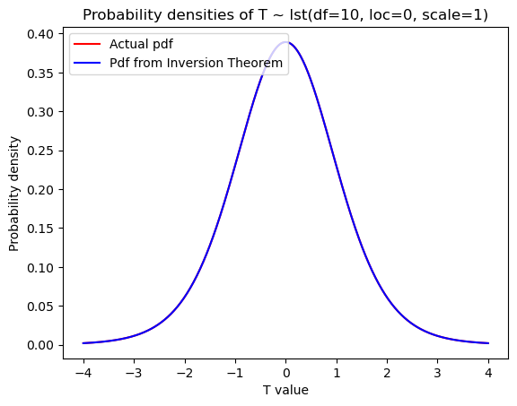

```python
t_pdf(10)
```

## Question 3:

Make a computer program that inputs 2 degrees of freedom values (such as 3 and 5, for which we have a simple c.f. expression, but the program should be general!) and plots, on the same plot, 3 lines:

- a.) the result of using the integral convolution formula for sums of two independent Student t random variables (with the degrees of freedom passed to the program). You will obviously need a numerical integration function, such as quadgk in Matlab. Let each distribution have zero location and unit scale term. In reality, these would not be 0 and 1, and would be passed to the function as well. For now, just use zero location and unit scale.
- b.) Another line in the plot is the same density, but obtained via simulation. HINT: In Matlab, use the function "ksdensity" (read its help file). Obviously, the more simulations you do, the smoother and more accurate the resulting kernel density plot will be. Matlab and surely all packages (R and Python) have built-in methods to simulate Student t.
- c.) The last line of the plot (and obviously use different color AND ADD A LEGEND TO THE PLOT) is obtained by using the characteristic function inversion formula. The two Student t random variables you are summing are independent, so this is very straightforward.

Note that the lines in the graphic should be essentially overlapping if you got everything correct. Again, be sure to add a "legend" to the graphic, as well as labeling the x and y axes, and have a title. And, in latex, add a caption to the graphic, and a label, so that in your written text, you refer to the graphic as \ref{labelname}. (Remember, part of this class is to help train you to write professional reports...)

```python
'''
Characteristic function of t-distribution
'''
def t_cf(df, t):
    # Avoid Bessel function
    if df == 3:
        return (1 + abs(t*np.sqrt(3))) * np.exp(-abs(t*np.sqrt(3)))

    elif df == 5:
        return (1 + abs(t*np.sqrt(5)) + 5/3 * t**2) * np.exp(-abs(t*np.sqrt(5)))

    # need to use Bessel function
    else:
        z = df/2
        x = np.sqrt(df) * abs(t)

        return ( special.kv(z, x) * x**(z) ) / ( special.gamma(z) * 2**(z - 1) )

def inv_t_cf(df, x):
    # define kernel of inversion theorem
    f = lambda t, x, df: 1/(2*np.pi) * np.exp(-complex(0,1)*t*x) * t_cf(df, t) #

    # integrate numerically
    res = integrate.quad_vec(f, -np.inf, np.inf,  args=(x, df))
    res_val = res[0]

    return res_val
```

```python
# plot X + Y distribution for
# X ~ lst(df1, loc, sig)
# Y ~ lst(df2, loc, sig)
def sum_tconv_pdf(s, df1, df2, mu=0, sig=1):
    # via convolution
    f = lambda x, df1, df2, mu, sig, s: stats.t.pdf(x, df1, loc=mu, scale=sig) * stats.t.pdf(s - x, df2, loc=mu, scale=sig)

    res = integrate.quad_vec(f, -np.inf, np.inf, args=(df1, df2, mu, sig, s))
    y = res[0]
    return y

# F(f_x (*) g_x) (s) = F(f_x)(s) * F(g(x))(s) = cf_f(s) * cf_g(s)
# convolution of X and Y pdfs is the inverse fourier transform of the product of their cfs
def inv_tsum_cf(s, df1, df2):
    # kernel to integrate
    f = lambda t, s, df1, df2: 1 / (2*np.pi) * np.exp(-complex(0,1)*t*s) * t_cf(df1, t) * t_cf(df2, t)

    # inversion theorem (inverse fourier transform)
    res = integrate.quad_vec(f, -np.inf, np.inf, args=(s, df1, df2))
    res_val = res[0]

    return res_val
```

```python
def t_sum_pdf(df1, df2, mu = 0, sig = 1):
    if (df1 < 5) and (df2 < 5):
        s = np.linspace(-10, 10, 1000)
    else:
        s = np.linspace(-6, 6, 1000)

    plt.figure()
    plt.title(f'Probability density function of Z = X + Y with \n X ~ lst(df={df1}, loc=0,scale=1) and Y ~ lst(df={df2}, loc=0, scale=1)')

    # via convolution
    z_conv = sum_tconv_pdf(s, df1, df2, mu, sig)

    plt.plot(s, z_conv, color = 'r', label='Convolution formula')

    # simulation and kernel density
    x = stats.t.rvs(df=df1, loc=mu, scale=sig, size= 100000)
    y = stats.t.rvs(df=df2, loc=mu, scale=sig, size= 100000)

    z_sim = x + y

    # given the large tails of low df t-distributions, only consider sample values in a given range
    # when constructing the kernel density estimate
    if (df1 <= 2.5) or (df2 <= 2.5):
        z_sim = np.sort(z_sim)
        indices = (-25 <= z_sim) & (z_sim <= 25)
        w = indices / len(indices)
        density = stats.gaussian_kde(z_sim, weights=w)
    else:
        density = stats.gaussian_kde(z_sim)

    plt.plot(s, density(s), color='b', label='Kernel density')


    # characteristic inversion
    y_inv = inv_tsum_cf(s, df1, df2)
    plt.plot(s, y_inv, color='k', label='Cf inversion')

    plt.legend(loc='upper left')
    plt.xlabel('Z = X + Y value')
    plt.ylabel('Probability density')
    plt.show()


    return
```

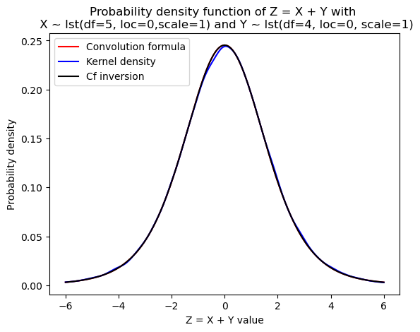

```python
t_sum_pdf(5, 4)
```

## Question 4:

- Note: Read the (important stuff, not all of it) appendix material from "Fundamental Statistics" on VaR and ES (I think it was section A.8), especially note the ES formula for the Student t. We need that. To get the VaR for the Student t, you just need to use a function built in to whatever computing language you use to get the quantile. For example, in Matlab it is: "tinv".

Program a function to input the parameters of the Student t (location, scale, df, and ESlevel), where ESlevel is the number in (0,1) indicating the tail probability --- make the default value for ESlevel 0.05. (That means, set up your codes so if ESlevel is not passed to the function, it defaults to 0.05.) Default for location is zero, and default for scale is 1.0. Out of the function comes the ES value. Notice this is the TRUE VALUE, computed from the formula in my book!

As said above, in our application, for location, you can take 0, and for scale, you can take 1.0. But your codes above input also the location and scale, and compute the ES based on this location-scale transform Student t. In reality, with real data, these would differ from these "base case" values of location zero and scale one, but for now, it is enough to work with the "standard" Student t.

```python
'''
Inputs:
    - mu = location parameter
    - sig = scale parameter
    - df = degrees of freedom
    - ESLevel = tail probability in calculating expected shortfall
Output:
    - Analytic (true) ES value
'''
def ES_t(df, mu = 0, sig = 1, ESLevel = 0.05):
    # Check input values
    if (ESLevel < 0) or (ESLevel > 1):
        print('ERROR: ESLevel must be in (0, 1)')
        return
    if (sig <= 0):
        print('ERROR: Scale parameter must be > 0')
        return
    if (df <= 1):
        print('ERROR: Degrees of freedom must be greater than 1 for finite first moment')

    # Compting ES via analytic formula
    c = stats.t.ppf(ESLevel, df = df, loc = mu, scale = sig)
    ES = -(stats.t.pdf(c, df=df, loc=mu, scale=sig) / stats.t.cdf(c, df=df, loc=mu, scale=sig)) * (df + c**2) / (df - 1)

    return ES
```

```python
ES_t(1000)
```

```
-2.0656595284508463
```

## Question 5:

Make a program that inputs a df value (it must be > 1 to ensure existence of the ES), and a sample size n (default 500), and a value B, the number of bootstrap replications (default 500 -- lower this if the computational burden is too much for your laptop). Use df=4 and n=250, but of course you can play with other values. The program generates a random data set of IID Student's t realizations (with location zero and scale 1.0 and the passed df value). (You can use a built-in generator, e.g., in Matlab, "trnd".) The output of the function is as follows:

- a.) the true ES (for a given ESlevel --- you can use 0.05), based on #6 above.
- b.) A 90% confidence interval of the ES, based on the *parametric* bootstrap. That means, the output is (a vector of) 2 values ---- the lower and upper endpoints of the confidence interval (CI). Let's fix 90%, keep it simple.

NOTE: You need the maximum likelihood estimator (MLE) for the location-scale Student t, applied to the simulated data set. You use the MLE parameter vector to generate samples of Student t for the bootstrap (use the single bootstrap, not the double). You do NOT use the true parameter values! (You will not have them in real life, right?) You compute the ES for each of the B resamples and then make a histogram, and extract, via sample quantiles (there is a function in Matlab for this) the lower and upper CI endpoints.

To compute the MLE of the IID location scale Student t, you may use built-in functions for the MLE of the Student t (see, e.g., for Matlab, the web page https://www.mathworks.com/help/stats/mle.html). Or, jump ahead in my book Fundamental Statistics, and see pages 141 and 142 for codes in Matlab to do this. Just copy-paste and use it!

- c.) Similar to #7b, but now with the nonparametric bootstrap and using the empirical estimator of the ES --- again, see the A.8 appendix.

For a n-length IID sequence of simulated Student t realizations, you need to compute the *EMPIRICAL* VaR, which can be done using Matlab's quantile function, or similar in other languages. Then, the EMPIRICAL ES is determined similarly, see for example page 445 of my book Fundamental Statistical Inference, the first "boxed" segment of code.

Then, you use the nonparametric bootstrap (see chapter 1) to draw with replacement from the simulated n-length sample of data, and compute again, B=500 times, the empirical VaR (the quantile) and the ES. From these 500 values, you generate the lower and upper limits of a 90% confidence interval.

```python
np.random.seed(100)
'''
Inputs:
    - df = degrees of freedom
    - n = simulation sample size
    - B = number of bootstraps
    - alpha = confidence interval level (1-alpha nominal coverage)
    - ESLevel = tail probability in calculating expected shortfall
Outputs
    - (ES, ci_par, ci_npar) = a tuple of the true expected shortfall estimate and its parametric and non-parametric confidence
                              intervals
'''
def ES_conf_t(df, n = 500, B = 500, alpha = 0.1, ESLevel = 0.05):
    # Input checks
    if df <= 1:
        print('ERROR: Degrees of freedom must be greater than 1 for finite first moment')
        return
    if (ESLevel < 0) or (ESLevel > 1):
        print('ERROR: ESLevel must be in (0, 1)')
        return

    # True ES value
    ES = ES_t(df = df, ESLevel = ESLevel)

    # Sample data
    samp = stats.t.rvs(df = df, size = n) # loc, scale = 0, 1


    ## Bootstrapping
    ES_est_par = np.zeros(B)
    ES_est_npar = np.zeros(B)

    # Parametric
    # no closed formed expression for MLEs. Numerically optimize:
    bounds = [(-np.inf, np.inf), (1e-5, np.inf), (1e-5, np.inf)]
    params0 = [0, 1, df]
    res = optimize.minimize(lst_loglikelihood, params0, method='L-BFGS-B', args=samp, bounds=bounds, tol=1e-3) # 1e-6

    # MLEs
    mu_mle, sig_mle, df_mle = res.x

    for b in range(B):
        # resample from mle fitted distribution
        resamp = stats.t.rvs(df = df_mle, loc = mu_mle, scale = sig_mle, size = n)

        # MLE fit again
        res2 = optimize.minimize(lst_loglikelihood, params0, method='L-BFGS-B', args=resamp, bounds=bounds, tol=1e-3) #1e-6

        # MLEs
        mu_mle_sim, sig_mle_sim, df_mle_sim = res2.x

        # Analytic ES value
        ES_est = ES_t(df = df_mle_sim, mu = mu_mle_sim, sig = sig_mle_sim, ESLevel = ESLevel)
        # Store
        ES_est_par[b] = ES_est

    # Get 90% parametric ci
    lb_par = np.quantile(ES_est_par, alpha/2)
    ub_par = np.quantile(ES_est_par, 1 - alpha/2)

    ci_par = [lb_par, ub_par]

    # Non parametric
    for b in range(B):
        # resample with replacement
        resamp = np.random.choice(samp, size = n)

        # Calculate empirical ES estimate
        # VaR cutoff
        VaR = np.quantile(resamp, ESLevel)

        # tail val indicator
        I_tailval = 1*(resamp < VaR)

        # empirical estimate
        ES_emp = (1/ESLevel) * np.mean(resamp * I_tailval)
        ES_est_npar[b] = ES_emp


    # Get 90% non parametric ci
    lb_npar = np.quantile(ES_est_npar, alpha/2)
    ub_npar = np.quantile(ES_est_npar, 1 - alpha/2)

    ci_npar = [lb_npar, ub_npar]

    return (ES, ci_par, ci_npar)
```

```python
ES_conf_t(df = 4, n = 250, B = 500)
```

```
(-3.2028703960846445,
 [-3.52354865236776, -3.121237481902742],
 [-3.327902513233255, -2.3419312658276583])
```

## Question 6:

Repeat #7 "sim" number of times, say 1000 (less if you have time issues), and record, for the parametric and nonparametric confidence intervals, the empirical ("actual") coverage probability. We hope that it is close to 90%, because the nominal coverage was set to 90%, right? Report these values.

Also report the average LENGTH of the "sim=1000" confidence intervals. That is, the high endpoint minus the low endpoint. We expect the parametric ones to be shorter, right?

```python
'''
Call the ES_conf_t function several times, record the proportion of times that the true ES value is in each confidence interval.
This will give actual coverage.
'''
def coverages(df, sim=1000, n=500, B=500):
    par_cover = np.zeros(sim)
    par_lengths = np.zeros(sim)
    npar_cover = np.zeros(sim)
    npar_lengths = np.zeros(sim)

    for i in range(sim):
        # simulate
        res = ES_conf_t(df=df, n = n, B = B) # should the parametric mle estimates be kept the same for each simulation?

        # true ES, parametric ci, and non parametric ci
        ES_true = res[0]
        ci_par = res[1]
        ci_npar = res[2]

        # lengths of the confidence intervals
        len_par = ci_par[1] - ci_par[0]
        par_lengths[i] = len_par
        len_npar = ci_npar[1] - ci_npar[0]
        npar_lengths[i] = len_npar

        if (ES_true <= ci_par[1]) and (ES_true >= ci_par[0]):
            par_cover[i] = 1

        if (ES_true <= ci_npar[1]) and (ES_true >= ci_npar[0]):
            npar_cover[i] = 1


    # actual coverages
    par_acov = np.mean(par_cover)
    print(f'Parametric 90% nominal, actual convergence: {par_acov}')
    par_avg_len = np.mean(par_lengths)
    print(f'average length: {par_avg_len} \n')

    npar_acov = np.mean(npar_cover)
    print(f'Non parametric 90% nominal, actual convergence: {npar_acov}')
    npar_avg_len = np.mean(npar_lengths)
    print(f'average length: {npar_avg_len} \n')

    return [[par_acov, par_avg_len], [npar_acov, npar_avg_len]]
```

```python
coverages(df=4, n=250)
```

```
Parametric 90% nominal, actual convergence: 0.867
average length: 0.4015408687290401

Non parametric 90% nominal, actual convergence: 0.833
average length: 1.481072476139079
```

```
[[0.867, 0.4015408687290401], [0.833, 1.481072476139079]]
```

```python
np.random.seed(1)

ns = [500, 1000, 1500, 2000, 4000, 7000, 10000]

p_acovs = np.array([])
np_acovs = np.array([])

for n in ns:
    print(n)
    sim_results = coverages(df = 10, sim = 1000, n = n) #try more sim /different df
    p_acovs = np.append(p_acovs, sim_results[0][0])
    np_acovs = np.append(np_acovs, sim_results[1][0])
```

```
500
Parametric 90% nominal, actual convergence: 0.989
average length: 0.3514565001765318

Non parametric 90% nominal, actual convergence: 0.852
average length: 0.5528773222096911

1000
Parametric 90% nominal, actual convergence: 0.936
average length: 0.17171829714909576

Non parametric 90% nominal, actual convergence: 0.869
average length: 0.39007872021642903

1500
Parametric 90% nominal, actual convergence: 0.924
average length: 0.12508926030813944

Non parametric 90% nominal, actual convergence: 0.883
average length: 0.3151052406136702

2000
Parametric 90% nominal, actual convergence: 0.905
average length: 0.10351005698964644

Non parametric 90% nominal, actual convergence: 0.896
average length: 0.272587210992407

4000
Parametric 90% nominal, actual convergence: 0.898
average length: 0.06728464571033098

Non parametric 90% nominal, actual convergence: 0.898
average length: 0.19240211287627357

7000
Parametric 90% nominal, actual convergence: 0.916
average length: 0.049418070844596755

Non parametric 90% nominal, actual convergence: 0.902
average length: 0.14591022263686426

10000
Parametric 90% nominal, actual convergence: 0.879
average length: 0.04095646155327316

Non parametric 90% nominal, actual convergence: 0.884
average length: 0.122318891405757
```

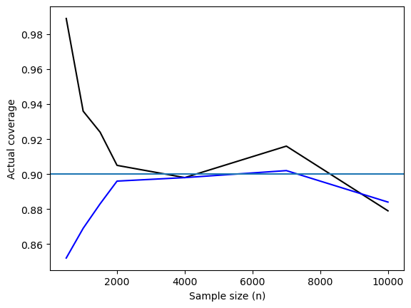

```python
# p_acovs = np.array([0.862, 0.86,  0.905, 0.886, 0.882, 0.89,  0.889, 0.906, 0.905, 0.9])
# np_acovs = np.array([0.8,   0.81,  0.856, 0.849, 0.877, 0.879, 0.862, 0.881, 0.885, 0.894])

plt.plot(ns, p_acovs, color='k', label='Parametric')
plt.plot(ns, np_acovs, color='b', label='Non parametric')
plt.ylabel('Actual coverage')
plt.xlabel('Sample size (n)')
plt.axhline(y=0.9)
plt.show()
```

[figure not shown]

```python
# p_acovs = np.array([0.862, 0.86,  0.905, 0.886, 0.882, 0.89,  0.889, 0.906, 0.905, 0.9])
# np_acovs = np.array([0.8,   0.81,  0.856, 0.849, 0.877, 0.879, 0.862, 0.881, 0.885, 0.894])

plt.plot(ns, p_acovs, color='k', label='Parametric')
plt.plot(ns, np_acovs, color='b', label='Non parametric')
plt.ylabel('Actual coverage')
plt.xlabel('Sample size (n)')
plt.axhline(y=0.9)
plt.show()
```

```python
print(p_acovs)
```

[output not shown]